# The Project

1. This is a project with minimal scaffolding. Expect to use the the discussion forums to gain insights! It’s not cheating to ask others for opinions or perspectives!
2. Be inquisitive, try out new things.
3. Use the previous modules for insights into how to complete the functions! You'll have to combine Pillow, OpenCV, and Pytesseract
4. There are hints provided in Coursera, feel free to explore the hints if needed. Each hint provide progressively more details on how to solve the issue. This project is intended to be comprehensive and difficult if you do it without the hints.

### The Assignment

Take a ZIP file) of images and process them, using a [library built into python](https://docs.python.org/3/library/zipfile.html) that you need to learn how to use. A ZIP file takes several different files and compresses them, thus saving space, into one single file. The files in the ZIP file we provide are newspaper images (like you saw in week 3). Your task is to write python code which allows one to search through the images looking for the occurrences of keywords and faces. E.g. if you search for "pizza" it will return a contact sheet of all of the faces which were located on the newspaper page which mentions "pizza". This will test your ability to learn a new ([library](https://docs.python.org/3/library/zipfile.html)), your ability to use OpenCV to detect faces, your ability to use tesseract to do optical character recognition, and your ability to use PIL to composite images together into contact sheets.

Each page of the newspapers is saved as a single PNG image in a file called images.zip. These newspapers are in english, and contain a variety of stories, advertisements and images. Note: This file is fairly large (~200 MB) and may take some time to work with, I would encourage you to use small_img.zip for testing.

Here's an example of the output expected. Using the small_img.zip file, if I search for the string "Christopher" I should see the following image:

[figure not shown]

If I were to use the images.zip file and search for "Mark" I should see the following image (note that there are times when there are no faces on a page, but a word is found!):

[figure not shown]

Note: That big file can take some time to process - for me it took nearly ten minutes! Use the small one for testing.

```python
import zipfile
from PIL import Image
import pytesseract
import cv2 as cv
import numpy as np

class WorkImage:
    # loading the face detection classifier as a class attribute
    face_cascade = cv.CascadeClassifier('readonly/haarcascade_frontalface_default.xml')


    # define the instance attributes
    def __init__(self, pil_img, file_name):
        self.file_name = file_name
        self.pil_img = pil_img
        self.bounding_boxes = list()
        self.text = ''
        self.scaleFactor = 1.15
        self.minNeighbors = 7
        self.minSize = (30, 30)
        self.maxSize = (300, 300)


    def faceDetectionAndDisplay(self, draw_b_boxes=0, face_cascade=face_cascade):  # detection should be improved as it is detecting other things
        # convert the PIL image into a numpy array in order to work with opencv
        #print(pil_image)
        img_array = np.asarray(self.pil_img)
        #print(type(img_array))

        # transform the numpy RGB array into a numpy GRAY array
        img_gray = cv.cvtColor(img_array, cv.COLOR_RGB2GRAY)

        # make the white background black to improve the detection
        #img_gray[img_gray == 255] = 0

        # although I am not sure what it does, this operation improves the detection
        img_gray = cv.equalizeHist(img_gray)

        # detect the faces in the image by calling the Haar cascade classifier, set the instance attribute bounding_boxes
        self.bounding_boxes = face_cascade.detectMultiScale(img_gray,
                                                            scaleFactor=self.scaleFactor,
                                                            minNeighbors=self.minNeighbors,
                                                            minSize=self.minSize,
                                                            maxSize=self.maxSize)


        if draw_b_boxes == 1:
            # draw bounding boxes
            for (x, y, w, h) in self.bounding_boxes:
                start_point = (x, y)  # top left
                end_point = (x + w, y + h)
                color = (255, 0, 255)
                thickness = 4
                img_array = cv.rectangle(img_array, start_point, end_point, color, thickness)

            detection = Image.fromarray(img_array)

            return detection


    def buildContactSheet(self):
        detected_faces = list()
        thumbnail_size = (128, 128) ##(w,h)

        for (x, y, w, h) in self.bounding_boxes:
            # create a cropping box as a (left, upper, right, lower)-tuple.
            box = (x, y, x + w, y + h)

            face_crop = self.pil_img.crop(box)

            if face_crop.width < thumbnail_size[0] or face_crop.height < thumbnail_size[1]:
                face_crop = face_crop.resize((128, 128))

            else:
                face_crop.thumbnail(thumbnail_size)

            detected_faces.append(face_crop)


        # define in initial x, y, cols and row_count values
        x = 0
        y = 0
        cols = 5
        row_count = 1

        # create a a base contact sheet
        contact_sheet = Image.new(self.pil_img.mode, (128 * cols, 128)) #(w, h)


        for detected_face in detected_faces:

            #  check x limit. if there is no more space in the row, add another one
            if x == contact_sheet.width:
                # update row_count value
                row_count += 1
                # create an empty contact sheet with space for another image
                extended_contact_sheet = Image.new(self.pil_img.mode, (128 *cols, 128 * row_count))
                # paste the old contact sheet into the empty-extended
                extended_contact_sheet.paste(contact_sheet)
                # assign the extended contact sheet as the current one
                contact_sheet = extended_contact_sheet
                # jump to the new row (x, y) position
                x = 0
                y += detected_face.height

            # paste current face in the contact sheet
            contact_sheet.paste(detected_face, (x, y))
            # update x and row_count values
            x += detected_face.width


            # resize and display the contact sheet
            #contact_sheet = contact_sheet.resize((int(contact_sheet.width / 2), int(contact_sheet.height / 2)))
        return contact_sheet


    def extract_text(self, draw_b_boxes=0):
        # load the pil_img
        img_array = np.asarray(self.pil_img)

        # convert to gray scale
        img_gray = cv.cvtColor(img_array, cv.COLOR_RGB2GRAY)

        # binarize the image with otsu thresholding and gaussian blur
        img_blur = cv.GaussianBlur(img_gray, (5, 5), 0)
        threshold = cv.threshold(img_blur, 0, 255, cv.THRESH_BINARY + cv.THRESH_OTSU)[1]

        #store the string in the text instance attribute
        self.text = pytesseract.image_to_string(threshold)

        if draw_b_boxes == 1:
            bounding_boxes = pytesseract.image_to_boxes(threshold)
            # draw bounding boxes
            #for (x, y, w, h) in bounding_boxes:
                #start_point = (x, y)  # top left
                #end_point = (x + w, y + h)
                #color = (255, 0, 255)
                #thickness = 4
                #img_array = cv.rectangle(img_array, start_point, end_point, color, thickness)

            #detection = Image.fromarray(img_array)

            return bounding_boxes


    def search_keyword(self, keyword):

        self.extract_text()

        if keyword in self.text:
            print("Results for {} found in {}".format(keyword, self.file_name))
            self.faceDetectionAndDisplay()

            if len(self.bounding_boxes) == 0:
                print("But no faces in that file")
                return None

            else:
                contact_sheet = self.buildContactSheet()
                return contact_sheet

        else:
            print("No match for {} in {}".format(keyword, self.file_name))
            return None
```

```
Results for Christopher found in a-0.png
```

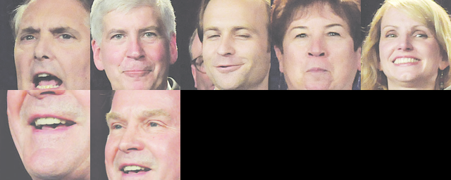

```
No match for Christopher in a-1.png
No match for Christopher in a-2.png
Results for Christopher found in a-3.png
```

[figure not shown]

```python
path = "readonly/small_img.zip"

processed_images = list()

with zipfile.ZipFile(path) as myzip:
    files = myzip.namelist()

    for file in files:

        with myzip.open(file) as my_img:

            with Image.open(my_img) as pil_img:
                work_image = WorkImage(pil_img, file)
                contact_sheet = work_image.search_keyword("Christopher")

                if contact_sheet == None:
                    pass
                else:
                    display(contact_sheet)
```

```
Results for Mark found in a-0.png
```

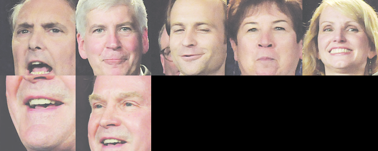

```
Results for Mark found in a-1.png
```

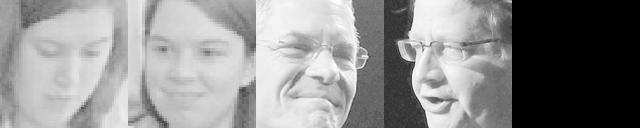

```
Results for Mark found in a-10.png
But no faces in that file
No match for Mark in a-11.png
No match for Mark in a-12.png
Results for Mark found in a-13.png
```

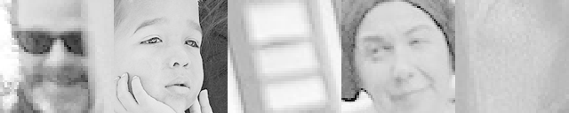

```
Results for Mark found in a-2.png
But no faces in that file
Results for Mark found in a-3.png
```

[figure not shown]

```
No match for Mark in a-4.png
No match for Mark in a-5.png
No match for Mark in a-6.png
No match for Mark in a-7.png
Results for Mark found in a-8.png
But no faces in that file
No match for Mark in a-9.png
```

```python
path = "readonly/images.zip"

processed_images = list()

with zipfile.ZipFile(path) as myzip:
    files = myzip.namelist()

    for file in files:

        with myzip.open(file) as my_img:

            with Image.open(my_img) as pil_img:
                work_image = WorkImage(pil_img, file)
                contact_sheet = work_image.search_keyword("Mark")

                if contact_sheet == None:
                    pass
                else:
                    display(contact_sheet)
```